# Is there a correlation Local Government CMS choice and Carbon Impact?

# Task

Is there a correlation between CMS platform and website carbon measurement in Local Government websites?

# Data Sources

Open Innovations publish monthly snapshots of council website emissions: https://open-innovations.github.io/council-website-emissions/ (data/council-website-emissions.csv)

Dave Briggs and Colin Stenning published the data on councils use of CMS systems: https://sensibletech.co.uk/what-content-management-systems-are-used-in-local-government/ and https://colinstenning.com/2021/11/10/cms-used-by-local-authorities/ (data/council-cms.csv)

# Data prep and processing

```r
#install packages
install.packages("urltools")
```

```r
library(tidyverse)  #helps wrangle data
library(ggplot2)  #helps visualize data
library(urltools) # helps format URLs
emissions_raw <- read_csv("csv/council-website-emissions.csv")
cms_raw <- read_csv("csv/council-cms.csv")
```

council-cms.csv

- Website URL is used as an identifier in an inconsistent format, most often: ..gov.uk
- Trailing slash usage is inconsistent
- 386 records
- CMS values are inconsistent (eg ‘WordPress’ vs ‘Wordpress’)

council-website-emissions.csv

- ONS Code is present as an identifier
- Website URL is present in an inconsistent format, most often: https://..gov.uk
- Trailing slash usage is inconsistent
- 408 records

```r
# First make a column with an extracted domain for the cms dataset
cms_urls = url_parse(cms_raw$`Council website`)
cms_domains = suffix_extract(cms_urls$domain)
cms = cbind(cms_raw, cms_domains)
View(cms)
# TODO
# Next lets make an extracted domain for the emissions dataset
emissions_urls = url_parse(emissions_raw$Website)
emissions_domains = suffix_extract(emissions_urls$domain)
emissions = cbind(emissions_raw, emissions_domains)
View(emissions)
```

## Merge data

First we need to get a dataset with all the data from council-website-emissions.csv + an extra column for the CMS, looked up from council-cms.csv.

```r
results = merge(emissions, cms, by = "domain", all = TRUE) %>%
  select(`ONS Code`, `Council name`, domain, CMS, `CO2 emissions (g)`)
# Make CMS names consistent
results$CMS[results$CMS == 'Wordpress'] <- 'WordPress'
results$CMS[results$CMS == 'Sharepoint'] <- 'SharePoint'
# Remove CMS Not Detected
results = subset(results, CMS!='CMS Not Detected')
```

# Analysis

- identify if cms usage is correlated to carbon emissions - each CMS - min, max and mean

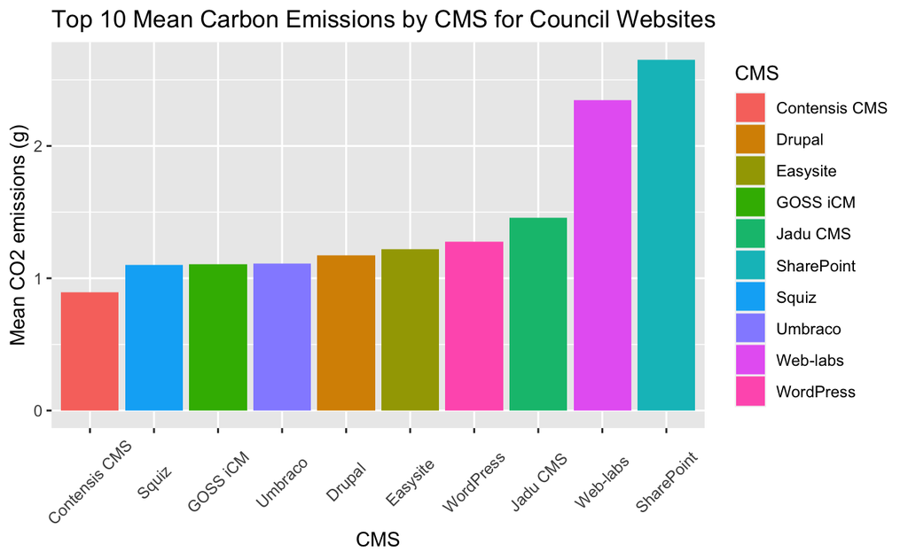

```r
temp = results %>%
    group_by(CMS) %>%
    summarise(
      `Mean CO2 emissions (g)` = mean(`CO2 emissions (g)`, na.rm = TRUE),
      `Median CO2 emissions (g)` = median(`CO2 emissions (g)`, na.rm = TRUE),
      `Min CO2 emissions (g)` = min(`CO2 emissions (g)`, na.rm = TRUE),
    `Max CO2 emissions (g)` = max(`CO2 emissions (g)`, na.rm = TRUE),
      `Website Count` = n(),
      )
# Calculate mean of CMS where we have enough instances
temp2 = temp %>%
  filter(`Website Count` > 4) %>%
  arrange(desc(`Mean CO2 emissions (g)`))
topten <- temp2[1:10,]

topten %>%
  ggplot(aes(x= reorder(CMS, `Mean CO2 emissions (g)`), y = `Mean CO2 emissions (g)`, fill=CMS)) +
  geom_col() +
  theme(axis.text.x=element_text(angle = 45, vjust = 0.5)) +
  ggtitle("Top 10 Mean Carbon Emissions by CMS for Council Websites") +
  xlab("CMS")
```

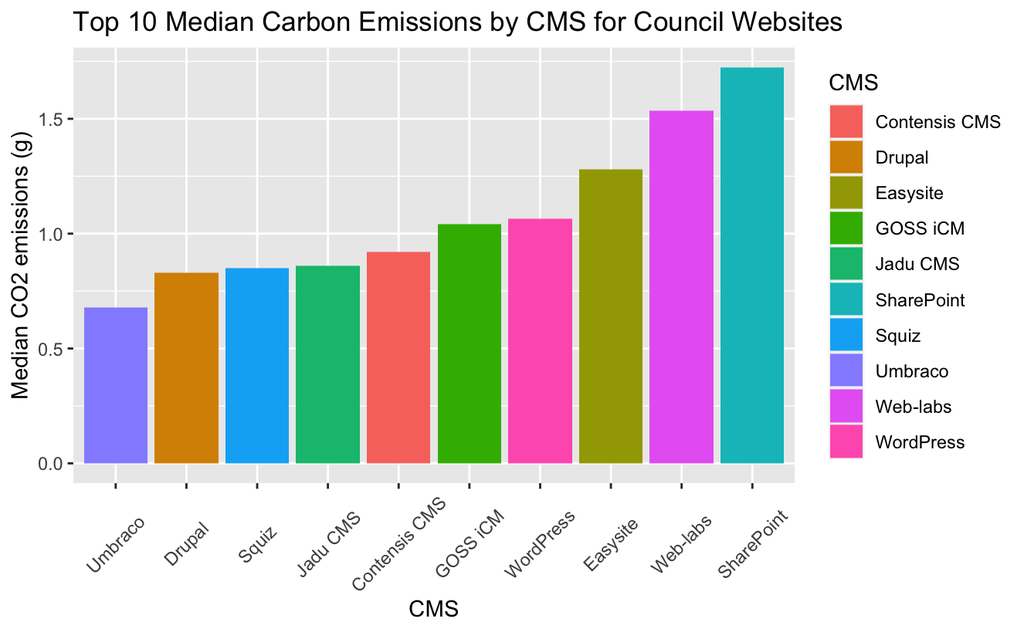

```r
temp2 = temp %>%
  filter(`Website Count` > 4) %>%
  arrange(desc(`Median CO2 emissions (g)`))
topten <- temp2[1:10,]

topten %>%
  ggplot(aes(x= reorder(CMS, `Median CO2 emissions (g)`), y = `Median CO2 emissions (g)`, fill=CMS)) +
  geom_col() +
  theme(axis.text.x=element_text(angle = 45, vjust = 0.5)) +
  ggtitle("Top 10 Median Carbon Emissions by CMS for Council Websites") +
  xlab("CMS")
```

```r
# TODO median - and compare with mean
```

```r
p = ggplot(results, aes(x= `CO2 emissions (g)`, y = CMS, colour=CMS)) + geom_point()
p + labs(title = "CO2 emissions (g) for Local Government Websites by CMS", subtitle = "October 2021")
```

[output not shown]

# Conclusions

Before drawing any conclusions, it is important to be aware that:

- **The CMS data and emissions samples were carried out at different time in 2021.** LocalGov CMS platforms don’t change regularly, but there is still a risk of incorrectly attributed emissions data, which becomes especially serious when looking at outliers and drawing incorrect conclusions
- Some CMS platforms do not have enough websites for any conclusions to be statistically significant

Given the above we can however conclude that there is no significant correlation between CMS platform and the emissions profile you want to achieve.

Of the more popular platforms, Contensis, GOSS and WordPress have the least website instances with high emissions.

Given the lack of significant correlation it suggests that a valuable place to focus more research may be answering “Is it better to focus on the specific content on the page above optimizing the source code, for example image size?”